# Assumptions & Diagnostics

## BLUE

- Best linear unbiased estimate of beta  
  Properties: Unbiased, Efficient (se minimum), Consistent (N decreases se)

## 6 assumptions

1. No measurement error
2. Correctly specified form
3. No omitted variables
4. Homoscedasticity
5. Independence among the residuals
6. Normally distributed residuals

## What happens if we violate assumptions?

1. Biased regression coefficients
2. Biased standard errors

## 6 assumptions

| Violated Regression Assumption | Coefficients | Standard Errors |
| --- | --- | --- |
| 1. Measured without error | Biased | Biased |
| 2. Correctly specified form | Biased | Biased |
| 3. Correctly specified model | Biased | Biased |
| 4. Homoscedasticity |  | Biased |
| 5. Independent Errors |  | Biased |
| 6. Normality of the Errors |  | Biased |

## How do we detect violations?

| Assumption | detect |
| --- | --- |
| 1. Measured without error | Reliability |
| 2. Correctly specified form | Residuals against predicted |
| 3. Correctly specified model | Theory |
| 4. Homoscedasticity | Residuals against predicted |
| 5. Independent Errors | Design |
| 6. Normality of the Errors | q-q plot or distribution |

load data

```r
library(readr)
a_data <- read.csv("diagnostics.csv")
library(broom)
model.1 <- lm(Anxiety ~ Stress + Support, a_data)
a_data<- augment(model.1)
a_data
```

```
##      Anxiety   Stress  Support   .fitted   .se.fit       .resid
## 1   10.18520  3.19813  6.16020  8.151923 0.2704493  2.033276513
## 2    5.58873  7.00840  8.90690  8.314146 0.2734319 -2.725415658
## 3    6.58500  6.17400 10.54330  7.058865 0.2149116 -0.473864657
## 4    8.95430  8.69884 11.46050  7.658469 0.3902372  1.295830824
## 5    7.59910  5.26707  5.55160  9.384625 0.2811396 -1.785524719
## 6    8.15600  5.12485  7.51170  8.254344 0.1978903 -0.098343724
## 7    9.08020  6.85380  8.55650  8.437805 0.2692328  0.642395321
## 8    3.41339  1.77080  4.10000  8.653253 0.3921852 -5.239863338
## 9    8.65810  3.75282  5.39130  8.812568 0.2654195 -0.154467550
## 10   4.84619  5.44990 13.91480  4.905906 0.3727378 -0.059716102
## 11   5.74215  5.62860 14.63820  4.589440 0.4065828  1.152710370
## 12   6.30689  0.87730  1.73650  9.552369 0.4998309 -3.245479183
## 13  10.62630  6.73299  5.14480 10.244731 0.4052039  0.381568746
## 14   6.74786  4.43970  7.39790  8.018000 0.2008110 -1.270139772
```

[output cut: 223 more lines]

## residuals are very important

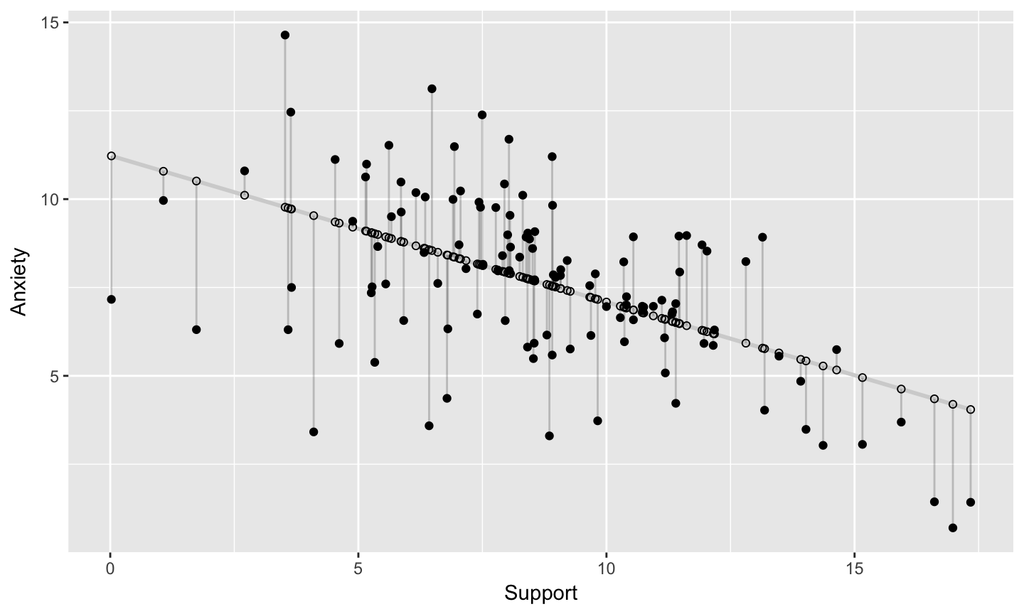

## with stress in the model

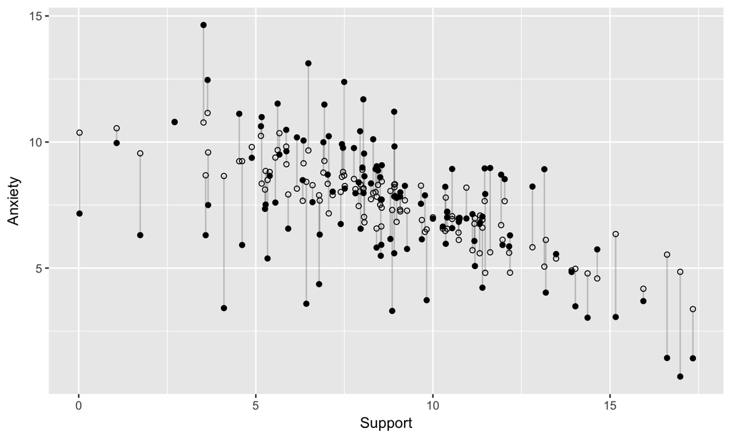

## Assumption 1: No measurement error in our independent variables

## Assumption 2: Correctly specified form

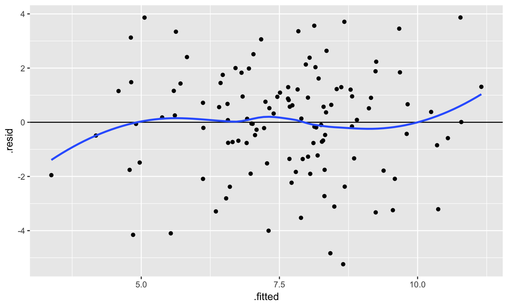

## Assumption 3: Correctly specified model

## Assumption 4: Homoscedasticity

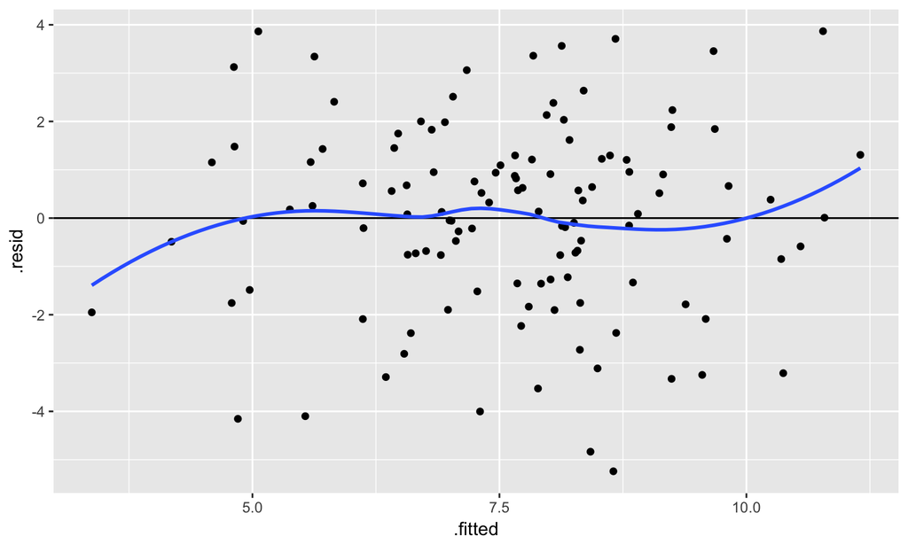

## Assumption 5: Independence among the errors

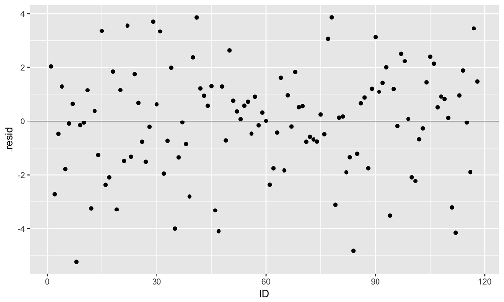

## Assumption 6: Normality of the errors

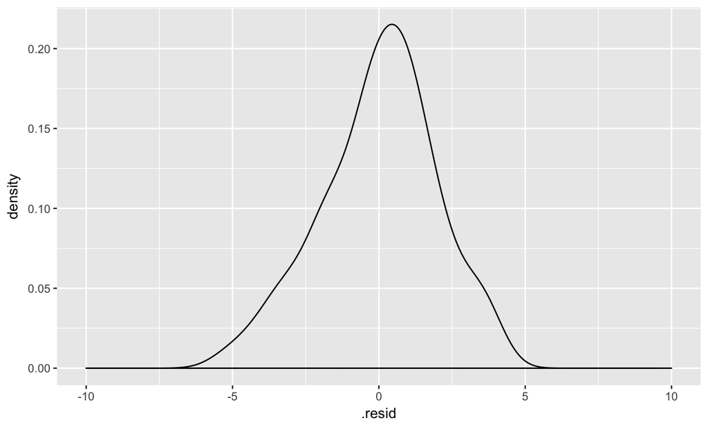

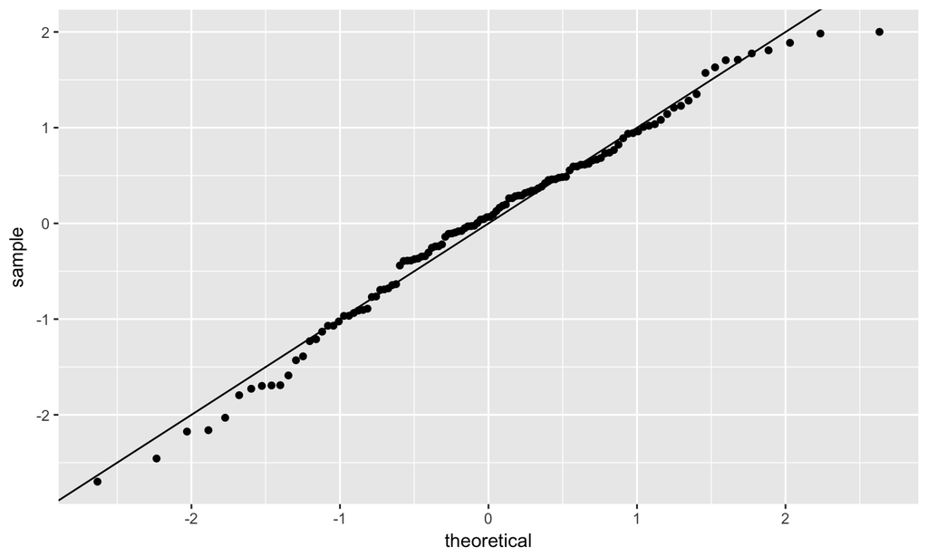

## car package also works

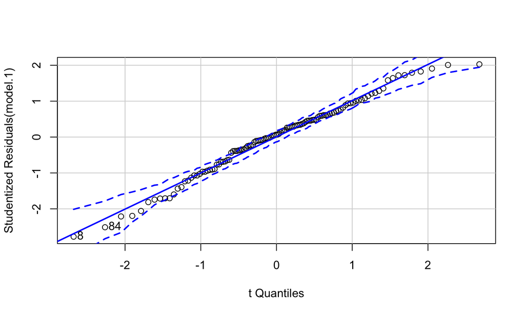

```
## [1]  8 84
```

```r
library(car)
qqPlot(model.1)
```

```r
#base plot function too
#plot(model.1, which = 2)
```

## How do we fix violations?

| Assumption | Fix |
| --- | --- |
| 1. Measured without error | Factor scores, SEM, more data |
| 2. Correctly specified form | Different model |
| 3. Correctly specified model | ¯`\_`(ツ)`_`/¯ |
| 4. Homoscedasticity | Bootstraps, WLS,transformations |
| 5. Independent Errors | Use differ method |
| 6. Normality of the Errors | Additional IVs, differnt form |

## Robustness?

- yeah, mostly
- especially with normally of errors
- note: we do not need to have normally distributed IVs or DVs

## Data screeing

- Start with descriptive stats and plots
- Look for outliers, missing cases, etc.
- Test assumptions (residual plots)

## why screen your data?

## Outliers

- Broadly defined as atypical or highly influential data point(s)
- Due to contamination (e.g. recording error) or accurate observation of a rare case
- Univariate vs. Multivariate

## Outliers

1. Leverage
   - How unusual is this case from the rest of the cases in terms of predictors?
2. Distance
   - How distant is the observed case from the predicted value?
3. Influence
   - How much the does regression coefficient change if case were removed?

## Leverage

- Tells us how far observed values for a case are from mean values on the set of IVs (centroid)
- Not dependent on Y values
- High leverage cases have greater potential to influence regression results
- Mahalanobis Distance for multivariate stats

## Distance

- Distance From Prediction- how far is observed value from predicted value (i.e. residuals)
- deleted residuals takes into consideration what would happen if case were deleted

## Influence

- How regression equation would change if extreme case were removed
- Influence = Leverage X Distance
- DFFITS (difference in fit standardized)
- Cooks D (same but different metric to DFFITS)
- DFBETAS (coefficient change without outlier)

## cooks d

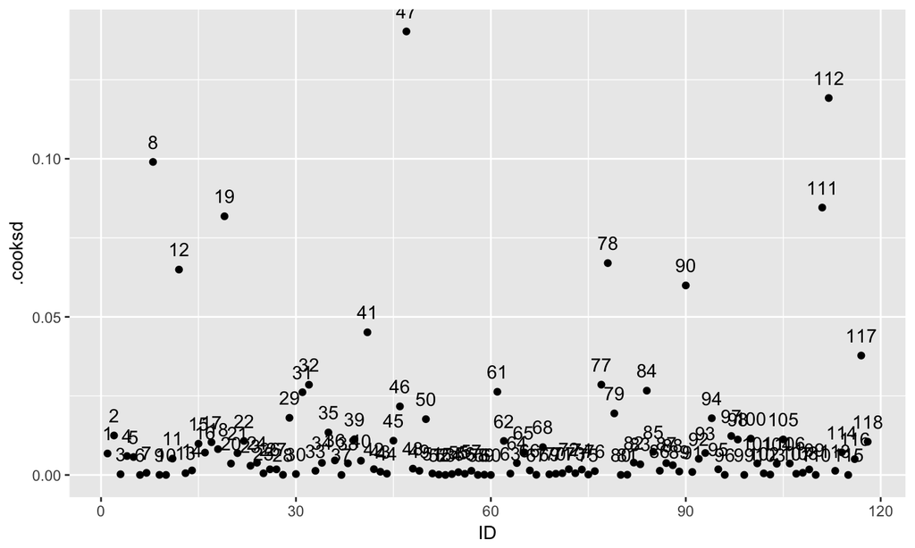

## df beta

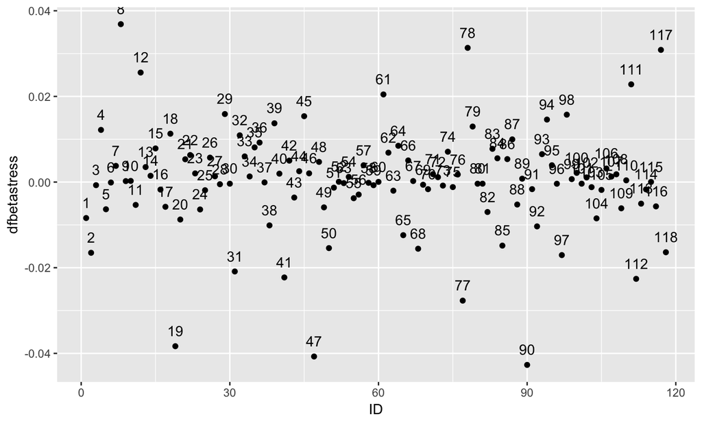

## recommendations

- Analyze data with/without outliers and see how results change
- If you throw out cases you must believe it is not representative of population of interest or have appropriate explanation